# COVID19 in the United States: Data by State and County

Analysis using New York Times data

Fernando DePaolis

github page https://github.com/fdepaolis

12 February, 2021

This site is under construction. Visit it again for updates

#### Introduction

In this project, we use the datasets available at the New York Times [github page](https://github.com/nytimes/covid-19-data). This site is updated daily.

The main dataset has confirmed cases and deaths by date and county or state (in two separate data files). We have developed the R code to read the datasets, limit the geography to states (i.e. removed territories) and started the process to clean up missing data. There are two types of missing data. For any given date, there are cases and death for which there is no county information (county and fips fields are ‘unknown’). The other type of missing cases is limited to New York and Missouri. For each state, the county field has a value “New York City” or “Kansas City” and the fips code is missing.

The main goal of this project is to provide a code that is easy to follow and results that are easy to reproduce. Feel free to copy the code and run it. We hope you find it useful.

For the main R code, we use functions in the following libraries:

- [RCurl](https://cran.r-project.org/web/packages/RCurl/) # Functions to compose general HTTP requests
- [tidyverse](https://cran.r-project.org/web/packages/tidyverse/) # Set of packages for data cleaning and reshaping data
- data.table # Fast aggregation of large data
- [reshape2](https://cran.r-project.org/web/packages/reshape2/) # Restructures/aggregates data using functions melt and ‘dcast’/ ’acast).

#### Reads data from github

```r
urlfile <- getURL("https://raw.githubusercontent.com/nytimes/covid-19-data/master/us-counties.csv")
cases_UScounties_full <- read.csv(text = urlfile)
```

#### Removes data for territories

```r
territ <- c("Guam","Virgin Islands",
            "Puerto Rico","Northern Mariana Islands")
cases_UScounties <- cases_UScounties_full
for (i in 1:4){
cases_UScounties <- subset(cases_UScounties,
        cases_UScounties$state !=territ[i])
}
```

#### Removes missing county data

```r
cases_UScounties <- subset(cases_UScounties_full,
                           cases_UScounties_full$county !="Unknown")

# some cases are assigned county== "Kansas City" or "New York City" with fips=='00NA' CONSIDER REMOVING
```

#### Reformats “fips” code to match NIST

####[it forces leading zero and to conform to fixed length of 5 charaters]

```r
# Adds a leading zero to 4-digit fips
cases_UScounties$fips <- sprintf("%05d",as.numeric(cases_UScounties$fips))
```

#### Adds new fields for “week” and “month”

```r
# 'month' field
cases_UScounties$month <- format(as.Date(cases_UScounties$date), "%Y-%m.%b")

# 'week' field with a label

cases_UScounties$week <- strftime(cases_UScounties$date, format = "%Y-week%V")
```

#### Creates new fields “new cases” and “new deaths”

(should be done by fips but it doesn’t work due to missing/misleading values–see comment above)

```r
#(using the lag function in dplyr)
cases_UScounties <- cases_UScounties %>%
                          group_by(state,county) %>%
                          mutate(new_cases = cases - dplyr::lag(cases))

cases_UScounties <- cases_UScounties %>%
                          group_by(state,county) %>%
                          mutate(new_deaths = deaths - dplyr::lag(deaths))

cases_UScounties[is.na(cases_UScounties)] = 0   # Revise
```

#### Summarizes by month

```r
data_by_month <- cases_UScounties %>%
                       group_by(state, month) %>%
                       summarize(sum(new_cases))

new_cases_by_month <- dcast(data_by_month,
                           state ~ month,
                           value.var = "sum(new_cases)"
                           )
```

#### Summarizes by week

```r
cases_UScounties$week.of <-  floor_date(as.Date(cases_UScounties$date), unit="week")

# summarize by week
data_by_week <- cases_UScounties %>%
                      group_by(state, week.of) %>%
                      summarize(sum(new_cases))

# pivot state by week
new_cases_by_week <- dcast(data_by_week,
                            state ~ week.of,
                            value.var = "sum(new_cases)"
                            )
```

New Cases by Month (partial-Last four months)

| state | 2020-11.Nov | 2020-12.Dec | 2021-01.Jan | 2021-02.Feb |
| --- | --- | --- | --- | --- |
| Alabama | 57239 | 111702 | 98413 | 17931 |
| Alaska | 16066 | 14273 | 7227 | 1850 |
| Arizona | 81084 | 196783 | 234747 | 34119 |
| Arkansas | 44786 | 67454 | 70042 | 15768 |
| California | 301944 | 1070577 | 1015844 | 136707 |
| Colorado | 126658 | 101077 | 61559 | 14859 |
| Connecticut | 45527 | 68450 | 64158 | 16400 |
| Delaware | 10683 | 21777 | 20569 | 3801 |

New Cases by Week (partial-Last six weeks)

| state | 2021-01-03 | 2021-01-10 | 2021-01-17 | 2021-01-24 | 2021-01-31 | 2021-02-07 |
| --- | --- | --- | --- | --- | --- | --- |
| Alabama | 29692 | 21531 | 18761 | 16140 | 15729 | 6259 |
| Alaska | 2109 | 1692 | 1463 | 1030 | 1022 | 959 |
| Arizona | 72738 | 58334 | 47359 | 38434 | 24173 | 12495 |
| Arkansas | 20172 | 18373 | 12694 | 11454 | 11624 | 5003 |
| California | 289162 | 287881 | 188966 | 145698 | 97260 | 53430 |
| Colorado | 20403 | 14606 | 10969 | 9688 | 10457 | 5420 |
| Connecticut | 15788 | 17379 | 14425 | 12173 | 9313 | 7087 |
| Delaware | 5587 | 4888 | 4530 | 3627 | 2282 | 2039 |

#### New Cases per Week by County ( Cook/Chicago, Los Angeles, Wayne/Detroit )

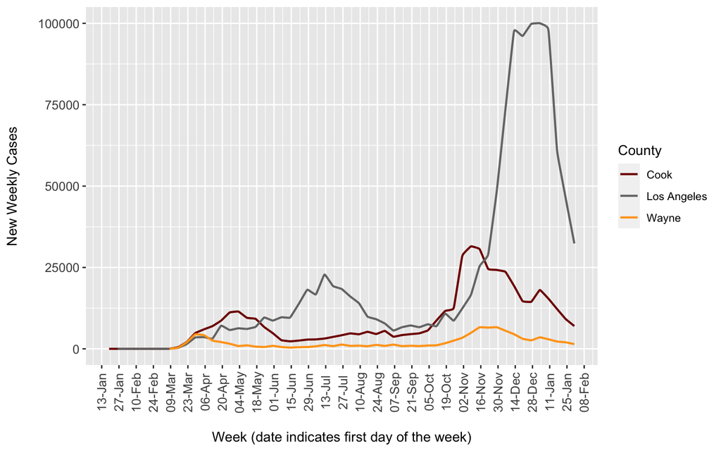